# Quality Control: Cell and Gene Filtering

Ramon Massoni-Badosa

2021/04/09

# 1 Introduction

The purpose of this notebook is to filter out poor quality cells and genes.

# 2 Pre-processing

## 2.1 Load packages

```r
library(Seurat)
library(ggpubr)
library(tidyverse)
```

## 2.2 Parameters

```r
# Paths
path_to_obj <- here::here("results/R_objects/2.seurat_unfiltered.rds")
path_to_project_metadata <- here::here("1-cellranger_mapping/data/richter_metadata.csv")
path_to_sample_metadata <- here::here("data/sample_metadata.csv")
path_to_save <- here::here("results/R_objects/3.seurat_filtered.rds")


# Functions
source(here::here("bin/utils.R"))


# Thresholds
min_lib_size <- 900
min_n_genes <- 250
max_pct_mt <- 22.5
min_cells <- 3
```

## 2.3 Load data

```r
# Read merged Seurat object
seurat <- readRDS(path_to_obj)
seurat
```

```
## An object of class Seurat
## 36618 features across 75497 samples within 2 assays
## Active assay: RNA (36601 features, 0 variable features)
##  1 other assay present: HTO
```

```r
# Read project and donor metadata
project_metadata_df <- read_csv(path_to_project_metadata)
DT::datatable(project_metadata_df)
```

|  | subproject | gem_id | library_id | library_name | type | donor_id |
| --- | --- | --- | --- | --- | --- | --- |
| 1 | BCLLATLAS_10 | xpsb8alg_mz7bsq6k | 140543 | ICGC_365 | hashed_cdna | ICGC_365 |
| 2 | BCLLATLAS_10 | xpsb8alg_mz7bsq6k | 140550 | ICGC_365_HTO | hashed_hto | ICGC_365 |
| 3 | BCLLATLAS_10 | r65huxjg_g0itbe2k | 140546 | ICGC_012_01 | hashed_cdna | ICGC_012 |
| 4 | BCLLATLAS_10 | r65huxjg_g0itbe2k | 140553 | ICGC_012_01_HTO | hashed_hto | ICGC_012 |
| 5 | BCLLATLAS_10 | bco1we6n_qaz6s7wd | 140547 | ICGC_012_02 | hashed_cdna | ICGC_012 |
| 6 | BCLLATLAS_10 | bco1we6n_qaz6s7wd | 140554 | ICGC_012_02_HTO | hashed_hto | ICGC_012 |
| 7 | BCLLATLAS_10 | te04uhdq_2uatjn5y | 140544 | ICGC_019_01 | hashed_cdna | ICGC_019 |
| 8 | BCLLATLAS_10 | te04uhdq_2uatjn5y | 140551 | ICGC_019_01_HTO | hashed_hto | ICGC_019 |
| 9 | BCLLATLAS_10 | j7z61du3_vyxon6q4 | 140545 | ICGC_019_02 | hashed_cdna | ICGC_019 |
| 10 | BCLLATLAS_10 | j7z61du3_vyxon6q4 | 140552 | ICGC_019_02_HTO | hashed_hto | ICGC_019 |

[output cut: 9 more lines]

```r
sample_metadata_df <- read_csv(path_to_sample_metadata)
DT::datatable(sample_metadata_df)
```

|  | donor_id | sample_id | tissue | time_point | sample_description | sampling_time | sample_description_FN | Exclude_FN |
| --- | --- | --- | --- | --- | --- | --- | --- | --- |
| 1 | 365 | 365-07 | PB | T2 | relapse1_post-R-Brenda | 7 | posttreatment |  |
| 2 | 365 | 14/2944 | PB |  | relapse2_post-RFCM | 4 |  | Sample excluded due to low quality in the other techniques |
| 3 | 365 | 15/194 | LN | T3 | richter_post-ofatu-duvelisib | 4 | RS |  |
| 4 | 19 | 04/67 | PB | T1 | diagnosis_sp | 5 | pretreatment |  |
| 5 | 19 | 11/2857 | PB | T3 | relapse1_post-chlorambucil | 4 | posttreatment |  |
| 6 | 19 | 19-06 | PB | T4 | relapse2_post-R-chlorambucil | 4 | posttreatment_2 |  |
| 7 | 19 | 19-12 | PB | T5 | relapse3_post-duve | 5 | posttreatment_3 |  |
| 8 | 19 | 18/3879A | PB | T6 | richter_while-ibrutinib | 7 | RS |  |
| 9 | 12 | 00/30 | PB | T1 | dx | 6 | pretreatment |  |
| 10 | 12 | 05/662 | PB | T2 | progression | 6 | pretreatment_progression |  |

[output cut: 12 more lines]

## 2.4 Add sample metadata

```r
sample_metadata_df$donor_id <- as.character(sample_metadata_df$donor_id)
seurat$donor_id <- seurat$donor_id %>%
  str_remove("ICGC_") %>%
  str_remove("^0")
seurat$subproject <- ifelse(seurat$is_hashed, "BCLLATLAS_10", "BCLLATLAS_29")
seurat$sample_id <- seurat$hash.ID
singlets <- colnames(seurat)[!(seurat$hash.ID %in% c("Negative", "Doublet"))]
seurat <- subset(seurat, cells = singlets)
seurat$sample_id <- seurat$sample_id %>%
  str_remove("(ICGC-012-|ICGC-019|ICGC-365-|ICGC-3299-)") %>%
  str_remove("^-")
seurat$sample_id[seurat$sample_id == "NA"] <- seurat$library_name[seurat$sample_id == "NA"]
seurat$sample_id <- str_replace(seurat$sample_id, "(-|_)", "/")
seurat$sample_id[seurat$sample_id == "365/07"] <- "365-07"
seurat$sample_id[seurat$sample_id == "19/06"] <- "19-06"
seurat$sample_id[seurat$sample_id == "19/12"] <- "19-12"
sample_metadata_df[sample_metadata_df$sample_id == "19/2768B", ]
```

```
## # A tibble: 1 x 8
##   donor_id sample_id tissue time_point sample_description             sampling_time sample_description_FN Exclude_FN
##   <chr>    <chr>     <chr>  <chr>      <chr>                                  <dbl> <chr>                 <chr>
## 1 3299     19/2768B  BM     T5         relapse3_post-ritux-cyclo-pred             5 RS_secondTimepoint    <NA>
```

```r
test_identifiers <- all(unique(sample_metadata_df$sample_id) %in% unique(sample_metadata_df$sample_id))
if (test_identifiers) {
  sample_metadata_df <- dplyr::select(sample_metadata_df, - "donor_id")
  new_metadata <- seurat@meta.data %>%
    left_join(sample_metadata_df, by = "sample_id") %>%
    as.data.frame()
  rownames(new_metadata) <- colnames(seurat)
  seurat@meta.data <- new_metadata

} else {
  stop("Identifiers are different!")
}


# Remove hashing-specific columns
removed_vars <- c("HTO_margin", "HTO_classification", "HTO_classification.global")
seurat@meta.data <- seurat@meta.data[, !(colnames(seurat@meta.data) %in% removed_vars)]
```

In addition, we see that Ferran included the variable “Exclude_FN” in the metadata:

```r
exclude_fn <- which(
  seurat$Exclude_FN == "Sample excluded due to low quality in the other techniques"
)
unique(seurat$sample_id[exclude_fn])
```

```
## [1] "14/2944"
```

As we can see, we can exclude the sample “14/2944” due to low quality in other techniques:

```r
seurat
```

```
## An object of class Seurat
## 36618 features across 56284 samples within 2 assays
## Active assay: RNA (36601 features, 0 variable features)
##  1 other assay present: HTO
```

```r
keep_cells <- colnames(seurat)[seurat$sample_id != "14/2944"]
seurat <- subset(seurat, cells = keep_cells)
seurat
```

```
## An object of class Seurat
## 36618 features across 55946 samples within 2 assays
## Active assay: RNA (36601 features, 0 variable features)
##  1 other assay present: HTO
```

# 3 Distribution of QC variables

First, we want to see how the main QC variables distribute across samples. This will help us interpret the results downstream, as we will know which are the samples with lower quality.

## 3.1 Signal-to-noise ratio (cell hashing)

```r
# Calculate mean SNR
snr_means_df <- seurat@meta.data %>%
  dplyr::filter(is_hashed) %>%
  dplyr::group_by(library_name) %>%
  dplyr::summarise(
    mean_snr = round(mean(hashing_snr), 2),
    sd_snr = round(sd(hashing_snr), 2)
  ) %>%
  dplyr::arrange(desc(mean_snr))
DT::datatable(snr_means_df)
```

|  | library_name | mean_snr | sd_snr |
| --- | --- | --- | --- |
| 1 | ICGC_3299_02 | 3.62 | 1.22 |
| 2 | ICGC_3299_01 | 3.49 | 1.19 |
| 3 | ICGC_019_01 | 3.35 | 1.53 |
| 4 | ICGC_019_02 | 3.03 | 1.42 |
| 5 | ICGC_012_02 | 2.74 | 1.26 |
| 6 | ICGC_365 | 2.55 | 1.46 |
| 7 | ICGC_012_01 | 2.44 | 1.09 |

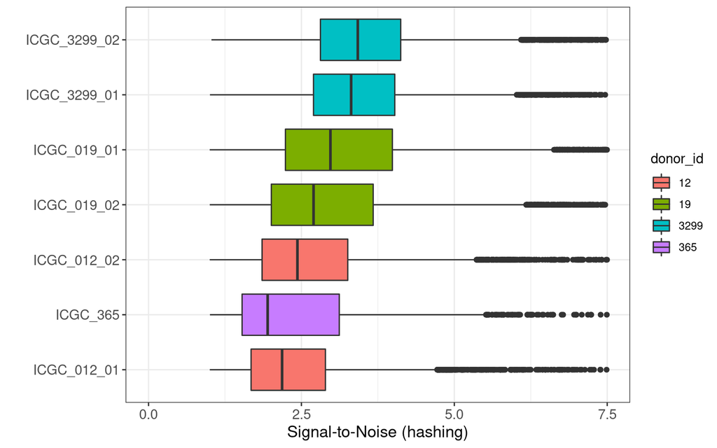

```r
# Plot SNR distribution
breaks <- c(0, 2.5, 5, 7.5)
snr_gg <- seurat@meta.data %>%
  dplyr::filter(is_hashed) %>%
  horizontal_boxplot(
    categorical_var = "library_name",
    continuous_var = "hashing_snr",
    fill = "donor_id",
    ylab = "Signal-to-Noise (hashing)"
  ) +
  scale_y_continuous(limits = c(0, 7.5), breaks = breaks)
snr_gg
```

## 3.2 Library complexity

```r
# Calculate mean library size
seurat_list <- SplitObject(seurat, split.by = "donor_id")
n_features_means_dfs <- purrr::map(seurat_list, function(seurat_obj) {
  df <- seurat_obj@meta.data %>%
    dplyr::group_by(time_point, sample_id) %>%
    dplyr::summarise(
      mean_n_features = round(mean(nFeature_RNA), 2),
      sd_n_features = round(sd(nFeature_RNA), 2)) %>%
    dplyr::arrange(time_point)
  df
})
n_features_means_dfs
```

```
## $`12`
## # A tibble: 5 x 4
## # Groups:   time_point [5]
##   time_point sample_id mean_n_features sd_n_features
##   <chr>      <chr>               <dbl>         <dbl>
## 1 T1         00/30               1206.          621.
## 2 T2         05/662               900.          963.
## 3 T4         19/911A             1239.          632.
## 4 T5         19/1543B            1212.          592.
## 5 T6         19/4600B            1746.         1519.
##
## $`19`
## # A tibble: 5 x 4
## # Groups:   time_point [5]
##   time_point sample_id mean_n_features sd_n_features
##   <chr>      <chr>               <dbl>         <dbl>
## 1 T1         04/67                799.          857.
## 2 T3         11/2857             1153.          704.
## 3 T4         19-06               1202.          692.
## 4 T5         19-12               1194.          738.
## 5 T6         18/3879A            1054.          683.
##
## $`3299`
## # A tibble: 4 x 4
## # Groups:   time_point [4]
##   time_point sample_id mean_n_features sd_n_features
##   <chr>      <chr>               <dbl>         <dbl>
## 1 T1         15/3257             1262.          519.
## 2 T2         17/251              1086.          661.
## 3 T3         18/218A             1182.          688.
## 4 T4         18/5761A            1568.          798.
##
## $`365`
## # A tibble: 2 x 4
## # Groups:   time_point [2]
##   time_point sample_id mean_n_features sd_n_features
##   <chr>      <chr>               <dbl>         <dbl>
## 1 T2         365-07              1730.          817.
## 2 T3         15/194              2049.         1610.
```

```
## $`12`
```

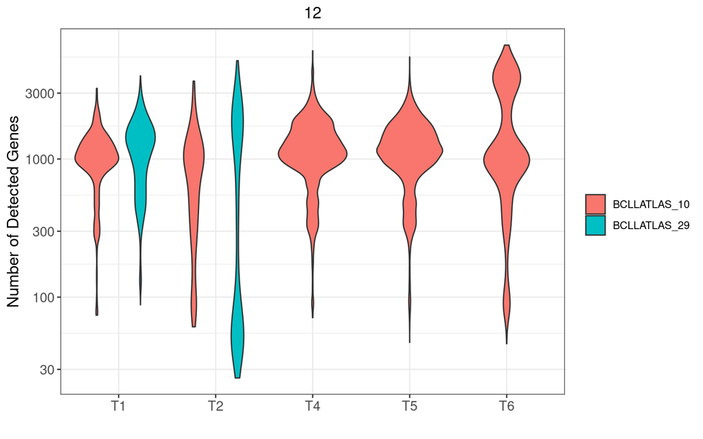

```
##
## $`19`
```

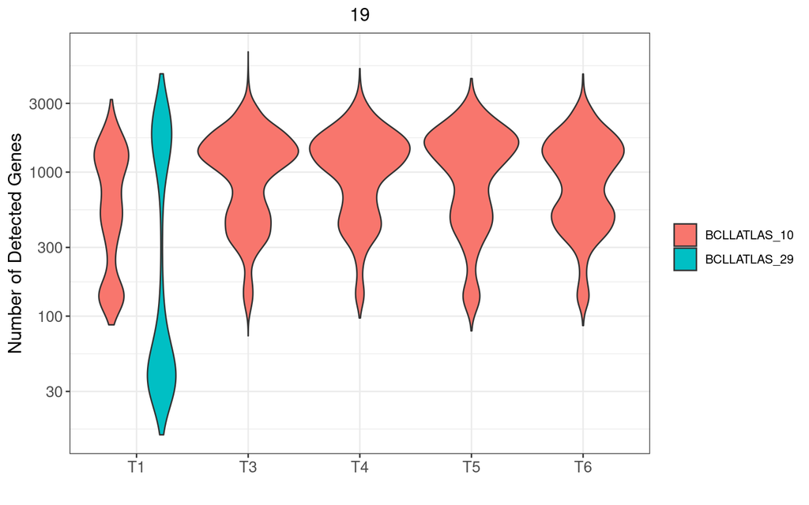

```
##
## $`3299`
```

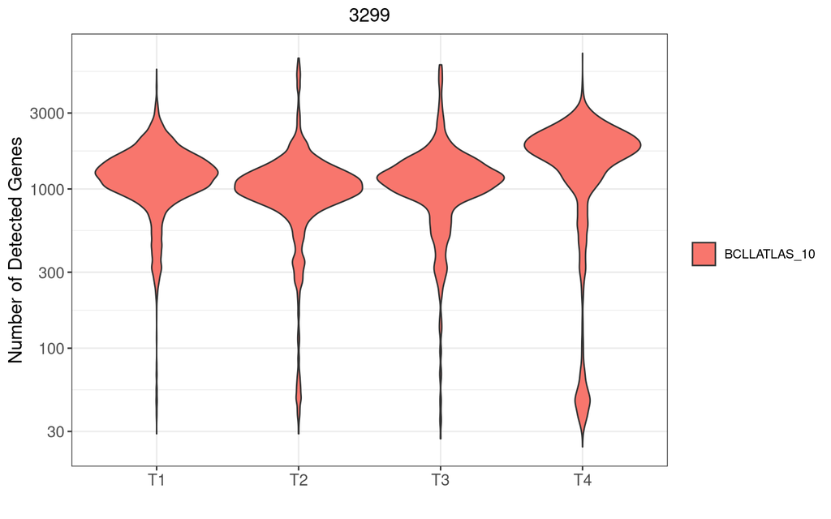

```
##
## $`365`
```

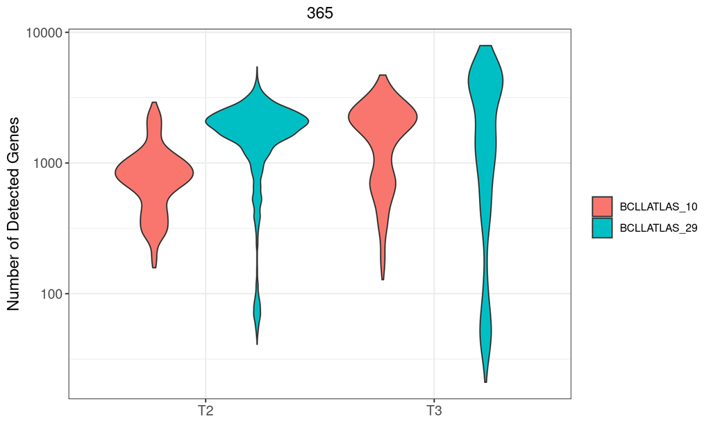

```r
# Plot library size distribution
n_features_ggs <- purrr::map(names(seurat_list), function(x) {
  p <- seurat_list[[x]]@meta.data %>%
    ggplot(aes(time_point, nFeature_RNA, fill = subproject)) +
      geom_violin() +
      scale_y_log10() +
      labs(title = x, x = "", y = "Number of Detected Genes") +
      theme_bw() +
      theme(
        plot.title = element_text(hjust = 0.5, size = 13),
        axis.text = element_text(size = 11),
        axis.title = element_text(size = 13),
        legend.title = element_blank()
      )
  p
})
names(n_features_ggs) <- names(seurat_list)
n_features_ggs
```

# 4 Filter out cells

We aim to detect and exclude empty droplets or lysed cells. Lysed cells have 3 hallmarks: (1) low library size (total UMI), (2) low library complexity (number of detected genes) and (3) high fraction of mitochondrial expression (cytosolic mRNA leaks out of the cell). Let us start by visualizing their univariate distributions.

## 4.1 Library Size

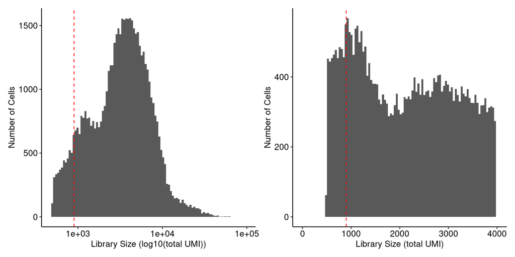

```r
lib_size_hist <- seurat@meta.data %>%
  plot_histogram_qc(x = "nCount_RNA", x_lab = "Library Size (log10(total UMI))") +
  geom_vline(xintercept = min_lib_size, linetype = "dashed", color = "red")
lib_size_hist1 <- lib_size_hist +
    scale_x_log10()
lib_size_hist2 <- lib_size_hist +
    scale_x_continuous(limits = c(0, 4000)) +
    xlab("Library Size (total UMI)") +
    theme_pubr()
lib_size_hist1 + lib_size_hist2
```

## 4.2 Number of detected genes

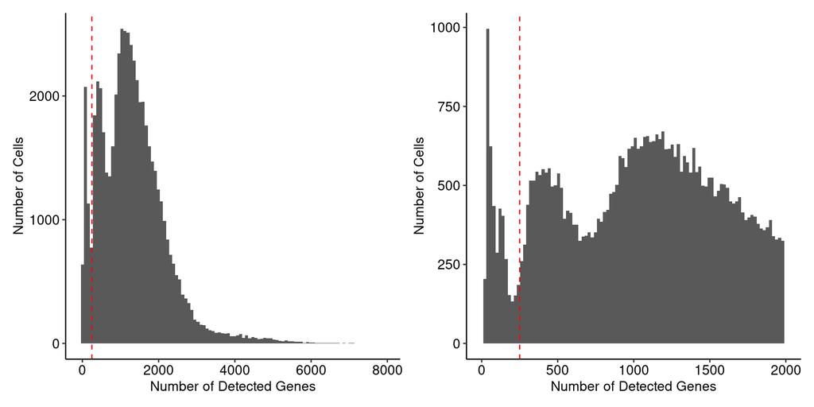

```r
n_genes_hist1 <- seurat@meta.data %>%
  plot_histogram_qc(x = "nFeature_RNA", x_lab = "Number of Detected Genes") +
  geom_vline(xintercept = min_n_genes, linetype = "dashed", color = "red")
n_genes_hist2 <- n_genes_hist1 +
  scale_x_continuous(limits = c(0, 2000))
n_genes_hist1 + n_genes_hist2
```

## 4.3 Fraction of mitochondrial expression

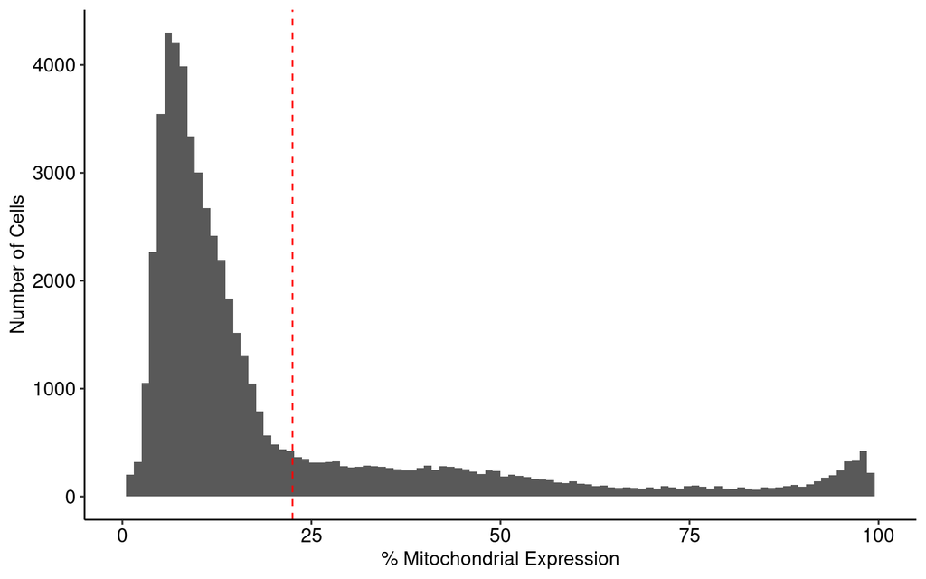

```r
# Calculate percentage of mitochondrial and ribosomal expression
seurat$pct_mt <- PercentageFeatureSet(seurat, pattern = "^MT-")


# Plot
pct_mt_hist <- seurat@meta.data %>%
  plot_histogram_qc(x = "pct_mt", x_lab = "% Mitochondrial Expression") +
  geom_vline(xintercept = max_pct_mt, linetype = "dashed", color = "red") +
  scale_x_continuous(limits = c(0, 100))
pct_mt_hist
```

## 4.4 Fraction of ribosomal expression

Let us also calculate and visualize the proportion of ribosomal expression:

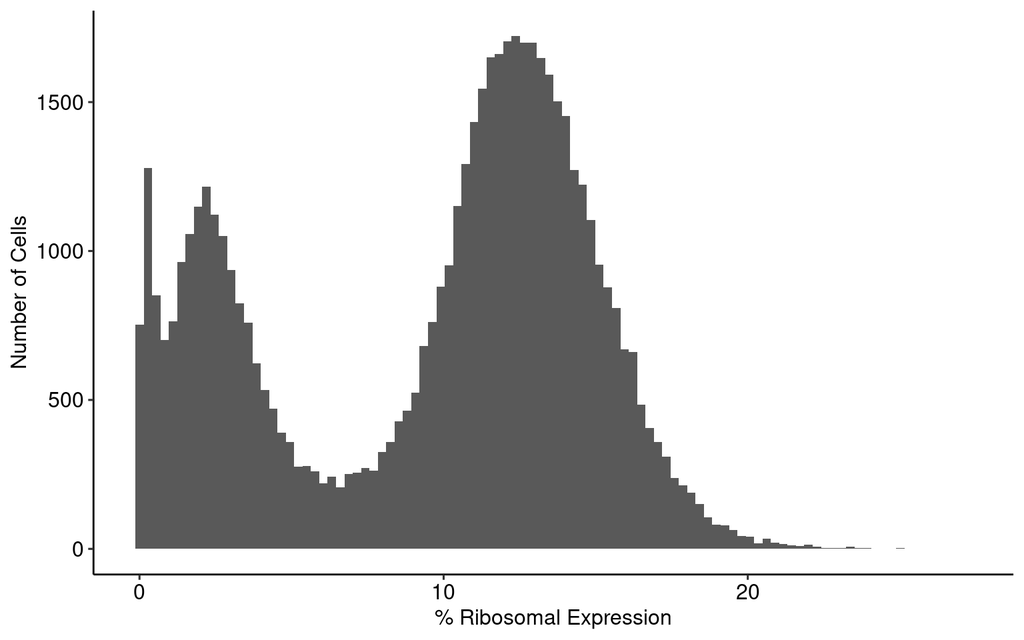

```r
seurat$pct_ribosomal <- PercentageFeatureSet(
  seurat,
  pattern = "^RPS"
)
pct_ribosomal_hist <- seurat@meta.data %>%
  plot_histogram_qc(x = "pct_ribosomal", x_lab = "% Ribosomal Expression")
pct_ribosomal_hist
```

## 4.5 Joint QC metrics

It is important to assess how these variables covary, since metabolically active cells might also have a high mitochondrial expression:

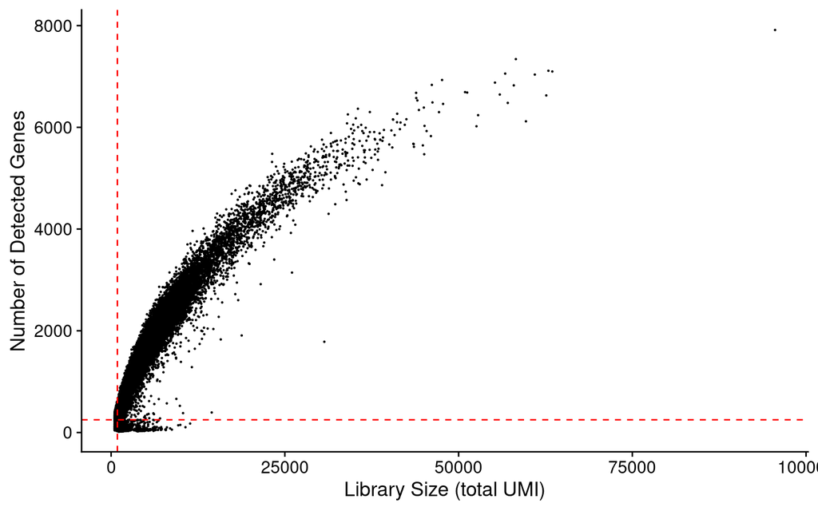

```r
# number of detected genes VS library size
n_genes_vs_lib_size <- FeatureScatter(
  seurat,
  feature1 = "nCount_RNA",
  feature2 = "nFeature_RNA",
  pt.size = 0.15,
  cols = rep("black", length(levels(Idents(seurat))))
)
n_genes_vs_lib_size <- n_genes_vs_lib_size +
  labs(x = "Library Size (total UMI)", y = "Number of Detected Genes") +
  theme(legend.position = "none", plot.title = element_blank())
n_genes_vs_lib_size +
  geom_vline(xintercept = min_lib_size, linetype = "dashed", color = "red") +
  geom_hline(yintercept = min_n_genes, linetype = "dashed", color = "red")
```

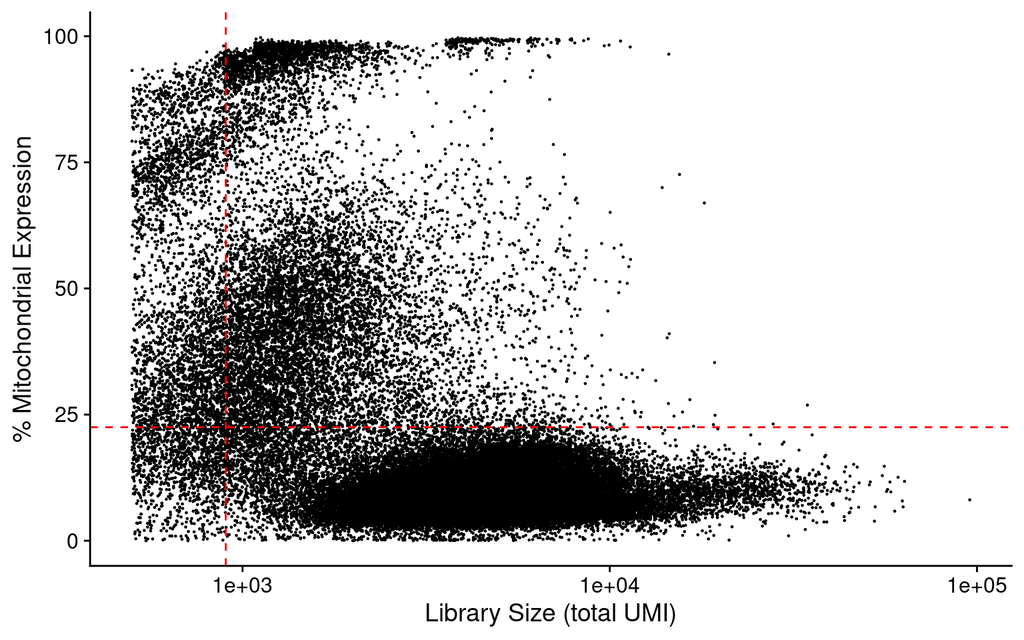

```r
# % mitochondrial expression VS library size
pct_mt_vs_lib_size <- FeatureScatter(
  seurat,
  feature1 = "nCount_RNA",
  feature2 = "pct_mt",
  pt.size = 0.15,
  cols = rep("black", length(levels(Idents(seurat))))
)
pct_mt_vs_lib_size <- pct_mt_vs_lib_size +
  scale_x_log10()+
  labs(x = "Library Size (total UMI)", y = "% Mitochondrial Expression") +
  theme(legend.position = "none", plot.title = element_blank())
pct_mt_vs_lib_size +
  geom_vline(xintercept = min_lib_size, linetype = "dashed", color = "red") +
  geom_hline(yintercept = max_pct_mt, linetype = "dashed", color = "red")
```

## 4.6 Subset empty droplets and lysed cells

```r
metadata_before_qc <- seurat@meta.data
is_low_quality <-
  seurat$nCount_RNA < min_lib_size |
  seurat$nFeature_RNA < min_n_genes |
  seurat$pct_mt > max_pct_mt
table(is_low_quality)
```

```
## is_low_quality
## FALSE  TRUE
## 40725 15221
```

```r
seurat
```

```
## An object of class Seurat
## 36618 features across 55946 samples within 2 assays
## Active assay: RNA (36601 features, 0 variable features)
##  1 other assay present: HTO
```

```r
seurat <- subset(seurat, cells = colnames(seurat)[!is_low_quality])
seurat
```

```
## An object of class Seurat
## 36618 features across 40725 samples within 2 assays
## Active assay: RNA (36601 features, 0 variable features)
##  1 other assay present: HTO
```

```r
metadata_after_qc <- seurat@meta.data
```

## 4.7 QC summary table

```r
qc_before <- metadata_before_qc %>%
  group_by(donor_id, sample_id, time_point) %>%
  summarise(num_cells_before_qc = n())
qc_after <- metadata_after_qc %>%
  group_by(donor_id, sample_id, time_point) %>%
  summarise(
    num_cells_after_qc = n(),
    average_library_size = mean(nCount_RNA),
    average_num_detected_genes = mean(nFeature_RNA),
    average_mitochondrial_fraction = mean(pct_mt)
  )
qc_table <- left_join(qc_before, qc_after, by = "sample_id")
DT::datatable(qc_table)
```

|  | donor_id.x | sample_id | time_point.x | num_cells_before_qc | donor_id.y | time_point.y | num_cells_after_qc | average_library_size | average_num_detected_genes | average_mitochondrial_fraction |
| --- | --- | --- | --- | --- | --- | --- | --- | --- | --- | --- |
| 1 | 12 | 00/30 | T1 | 7024 | 12 | T1 | 5684 | 3977.26935256861 | 1387.93754398311 | 7.00516400224978 |
| 2 | 12 | 05/662 | T2 | 1129 | 12 | T2 | 468 | 5240.82264957265 | 1846.25 | 11.5219975823946 |
| 3 | 12 | 19/1543B | T5 | 4015 | 12 | T5 | 3390 | 3773.15280235988 | 1362.67610619469 | 6.9918630992324 |
| 4 | 12 | 19/4600B | T6 | 3218 | 12 | T6 | 2299 | 9096.55719878208 | 2196.09047411918 | 8.66573239035021 |
| 5 | 12 | 19/911A | T4 | 2480 | 12 | T4 | 2123 | 3745.68111163448 | 1380.6302402261 | 6.97935075048381 |
| 6 | 19 | 04/67 | T1 | 2656 | 19 | T1 | 957 | 5662.87356321839 | 1728.3301985371 | 13.7872651133046 |
| 7 | 19 | 11/2857 | T3 | 5530 | 19 | T3 | 3390 | 4754.91474926254 | 1566.91681415929 | 12.8590432111617 |
| 8 | 19 | 18/3879A | T6 | 4263 | 19 | T6 | 2279 | 4380.1351469943 | 1519.00131636683 | 12.6876463894973 |
| 9 | 19 | 19-06 | T4 | 2722 | 19 | T4 | 1757 | 4998.34832100171 | 1562.55663062038 | 13.0303231708153 |
| 10 | 19 | 19-12 | T5 | 2112 | 19 | T5 | 1244 | 5166.48954983923 | 1665.53617363344 | 13.7767503174584 |

[output cut: 6 more lines]

# 5 Filter out genes

According to [Luecken MD et al.](https://www.embopress.org/doi/10.15252/msb.20188746): “A guideline to setting this threshold is to use the minimum cell cluster size that is of interest and leaving some leeway for dropout effects. For example, filtering out genes expressed in fewer than 20 cells may make it difficult to detect cell clusters with fewer than 20 cells. For datasets with high dropout rates, this threshold may also complicate the detection of larger clusters. The choice of threshold should scale with the number of cells in the dataset and the intended downstream analysis.”

## 5.1 Set threshold

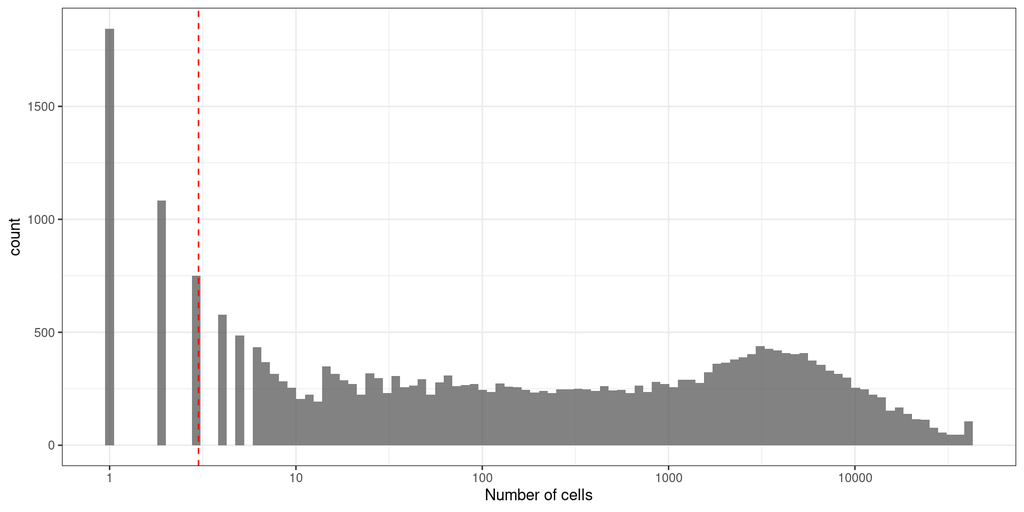

```r
n_cells <- Matrix::rowSums(seurat[["RNA"]]@counts > 0)
gene_qc <- n_cells %>%
  as.data.frame() %>%
  ggplot(aes(n_cells)) +
    geom_histogram(bins = 100, alpha = 0.75) +
    scale_x_log10("Number of cells") +
    theme_bw()
gene_qc +
  geom_vline(xintercept = min_cells, linetype = "dashed", color = "red")
```

## 5.2 Plot genes with highest expression

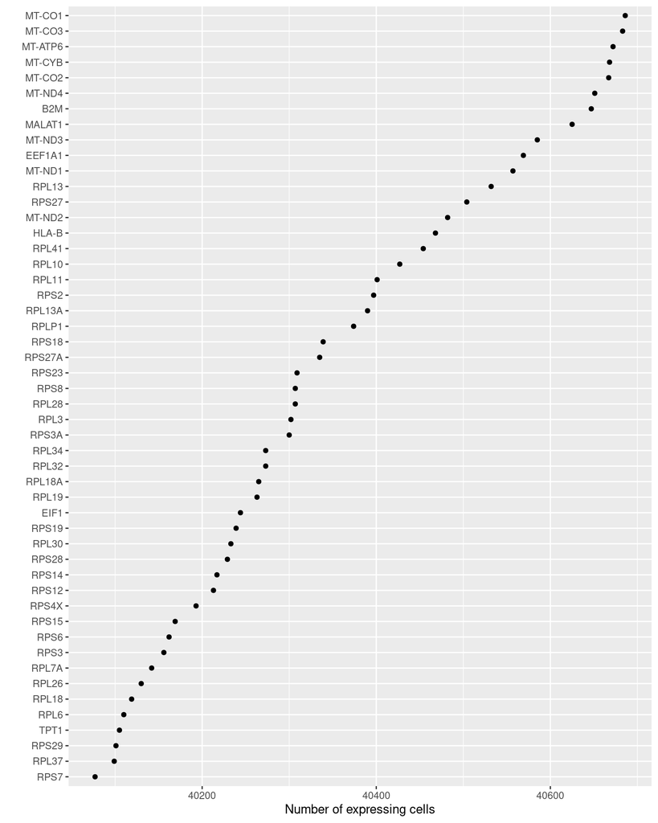

```r
top_50_genes <- sort(n_cells, decreasing = TRUE)[1:50]
top_50_genes_df <- data.frame(
  gene = names(top_50_genes),
  n_cells = top_50_genes
)
top_50_genes_gg <- top_50_genes_df %>%
  ggplot(aes(fct_reorder(gene, n_cells), n_cells)) +
    geom_point() +
    labs(x = "", y = "Number of expressing cells") +
    coord_flip()
top_50_genes_gg
```

## 5.3 Filter

```r
kept_genes <- rownames(seurat)[n_cells > min_cells]
table(n_cells > min_cells)
```

```
##
## FALSE  TRUE
## 13275 23326
```

```r
seurat
```

```
## An object of class Seurat
## 36618 features across 40725 samples within 2 assays
## Active assay: RNA (36601 features, 0 variable features)
##  1 other assay present: HTO
```

```r
seurat <- subset(seurat, features = kept_genes)
seurat
```

```
## An object of class Seurat
## 23326 features across 40725 samples within 1 assay
## Active assay: RNA (23326 features, 0 variable features)
```

# 6 Save filtered Seurat object

```r
saveRDS(seurat, path_to_save)
```